# Влияние модераторов на посещение форума. Выживаемость

## 1. Об отчете

### Исследовательские вопросы

1. Как длительность прохождения курса влияет на количество посещений форума?
2. Как посещение форума варьируется в зависимости от курса?
3. Как нормализованная длительность прохождения курса влияет на нормализованное посещение форума?

## Содержание отчета

1. Связь между типом курса и средним посещением форума на курсе
2. Связь между выживаемостью на курсе и средним посещением форума на курсе
3. Связь между нормализованной активностью студентов и нормализованной активностью модераторов на форуме;
4. Связь между выживаемостью на курсе и нормализованной активностью студентов и модераторов;

### Описание баз данных

- **courses** - короткая база данных, с данными на уровне курсов

### Описание переменных

- **Метрики форума**
  - *student_vis_mean* - среднее посещение форума студентами на курсе;
  - *ans_learner* - абсолютное количество ответов студентов на курсе;
  - *q_learner* - абсолютное количество вопросов студентов на курсе;
  - *ans_learner_n* - количество ответов студентов на курсе / количество студентов на курсе;
  - *q_learner_n* - количество вопросов студентов на курсе / количество студентов на курсе;
- **Метрики активности модераторов**
  - *ans_staff* - абсолютное количество ответов модераторов на курсе;
  - *q_staff* - абсолютное количество вопросов модераторов на курсе;
  - *ans_staff_b* - отвечали ли модераторы на вопросы на курсе (1 от 10 ответов);
  - *q_staff_b* - задавали ли модераторы вопросы на курсе (1 от 10 вопросов);
  - *ans_staff_n* - (количество ответов модераторов / количество студентов) *100;
  - *q_staff_n* - (количество вопросов модераторов / количество студентов) * 100;
- **Метрика выживаемости**
  - *passing_rate* - прошедшие курс / записавшиеся на курс

## 3. Модераторы и их влияние

### 3.1 Описание переменных и обоснование их выбора

```
## Распределение переменной q_staff_n:
```

```
##
##   0   1   2   3   4   5   7  10  11  18  24 440
##  42   4   2   3   2   1   1   1   1   1   1   1
```

```
##
## Распределение переменной ans_staff_n:
```

```
##
##   0   1   2   3   5   6   7  11  12  13  15  17  19  24  27  28  30  42  50  56
##  23   2   2   4   3   1   2   2   1   2   1   1   1   1   2   2   1   1   1   1
##  86 103 120 125 222 336
##   1   1   1   1   1   1
```

```
## Распределение переменной q_staff_b:
```

```
##
##  0  1
## 42 18
```

```
##
## Распределение переменной ans_staff_b:
```

```
##
##  0  1
## 23 37
```

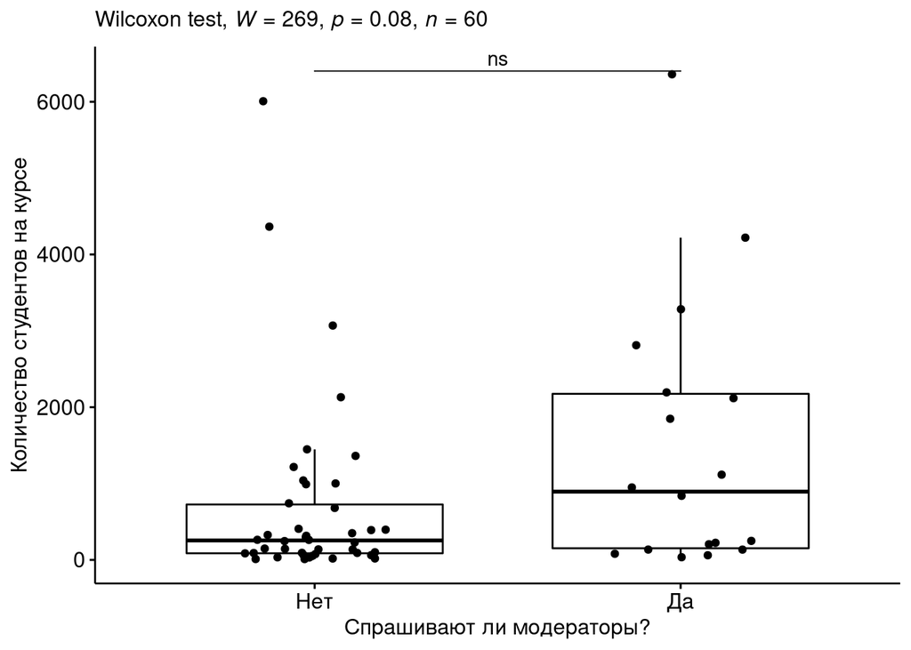

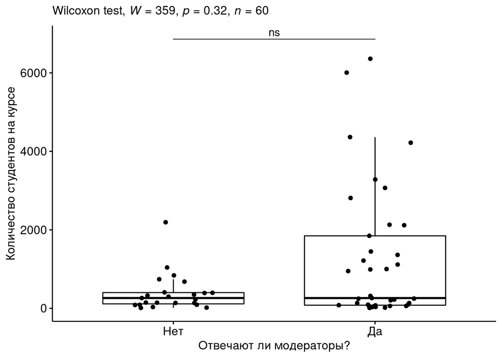

[output not shown]

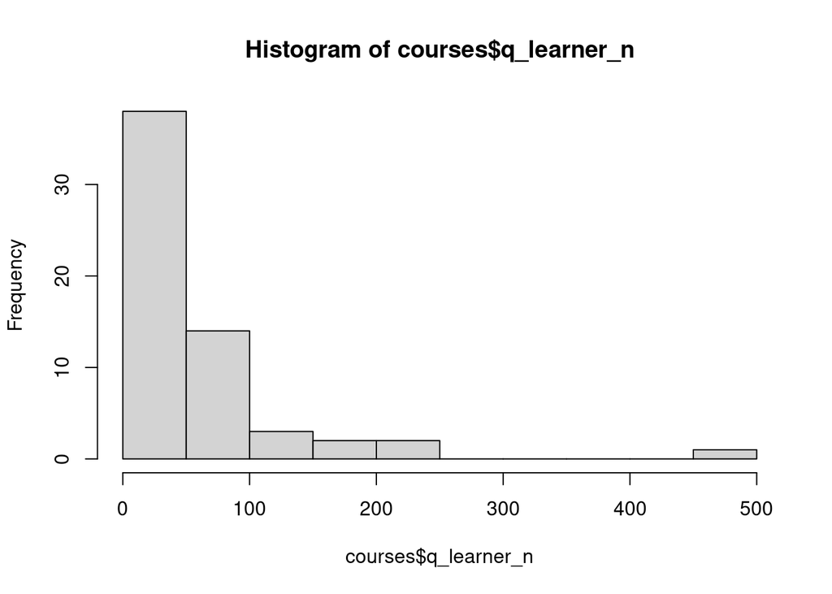

```r
hist(courses$q_learner_n)
```

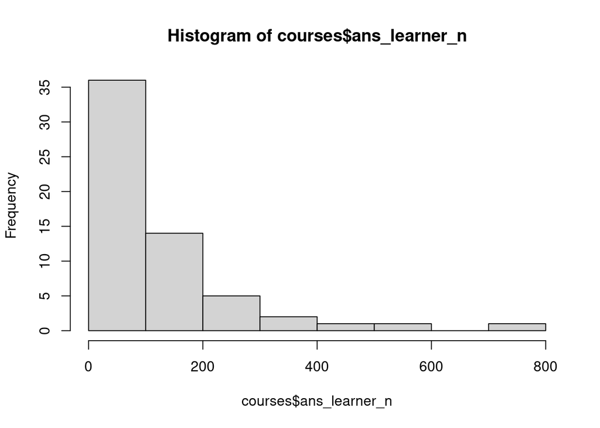

```r
hist(courses$ans_learner_n)
```

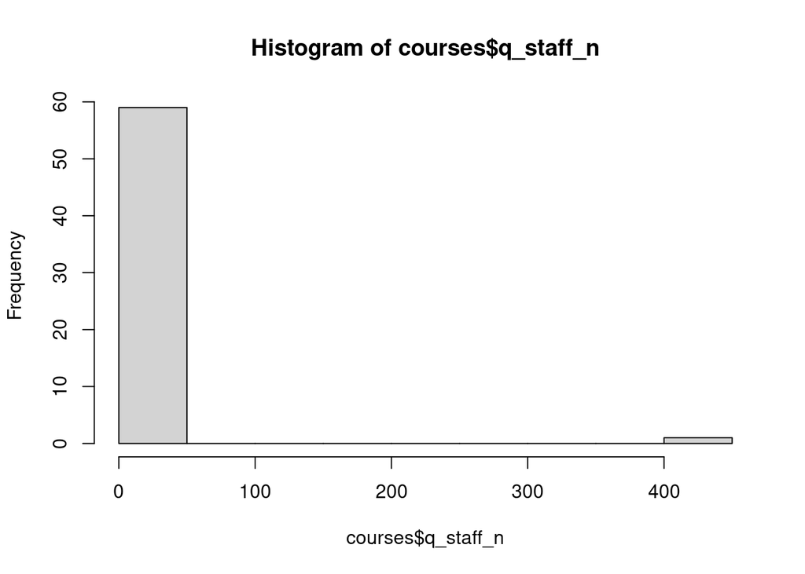

```r
hist(courses$q_staff_n)
```

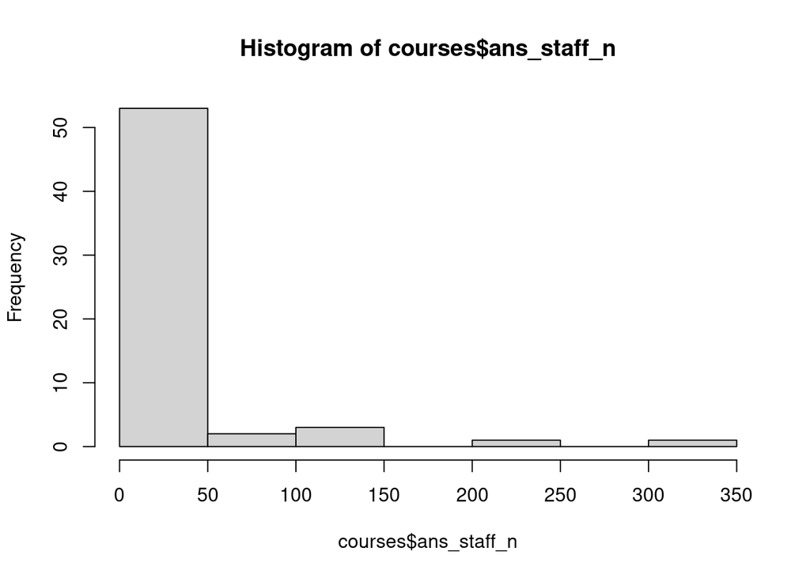

```r
hist(courses$ans_staff_n)
```

### 3.2 Рассчеты

### 3.2.1 Влияние модераторской активности на вопросы пользователей

```r
m1 <-  glm.nb(q_learner ~ q_staff_b + ans_staff_b, courses)
summary(m1)
```

```
##
## Call:
## glm.nb(formula = q_learner ~ q_staff_b + ans_staff_b, data = courses,
##     init.theta = 0.4708776101, link = log)
##
## Deviance Residuals:
##     Min       1Q   Median       3Q      Max
## -2.4721  -1.1148  -0.7657  -0.3706   2.5034
##
## Coefficients:
##             Estimate Std. Error z value Pr(>|z|)
## (Intercept)   4.7391     0.3069  15.442   <2e-16 ***
## q_staff_b     0.1074     0.4417   0.243   0.8078
## ans_staff_b   0.9954     0.4165   2.390   0.0168 *
## ---
## Signif. codes:  0 '***' 0.001 '**' 0.01 '*' 0.05 '.' 0.1 ' ' 1
##
## (Dispersion parameter for Negative Binomial(0.4709) family taken to be 1)
##
##     Null deviance: 82.331  on 59  degrees of freedom
## Residual deviance: 75.839  on 57  degrees of freedom
## AIC: 744.63
##
## Number of Fisher Scoring iterations: 1
##
##
##               Theta:  0.4709
##           Std. Err.:  0.0720
##
##  2 x log-likelihood:  -736.6290
```

```r
tab_model(m1)
```

|  | q learner |  |  |
| --- | --- | --- | --- |
| Predictors | Incidence Rate Ratios | CI | p |
| (Intercept) | 114.33 | 66.31 – 221.88 | **<0.001** |
| q_staff_b | 1.11 | 0.46 – 2.83 | 0.808 |
| ans_staff_b | 2.71 | 1.14 – 6.36 | **0.017** |
| Observations | 60 |  |  |
| R<sup>2</sup> Nagelkerke | 0.137 |  |  |

```
## Если модераторы форума отвечают на вопросы, то это увличивает ожидаемое количество вопросов пользователей в 2.71 раз.
```

### 3.2.2 Влияние модераторской активности на ответы пользователей

```r
m1 <-  glm.nb(ans_learner ~ q_staff_b + ans_staff_b, courses)
summary(m1)
```

```
##
## Call:
## glm.nb(formula = ans_learner ~ q_staff_b + ans_staff_b, data = courses,
##     init.theta = 0.3397372307, link = log)
##
## Deviance Residuals:
##     Min       1Q   Median       3Q      Max
## -2.4898  -1.2615  -0.8326  -0.3604   2.0726
##
## Coefficients:
##             Estimate Std. Error z value Pr(>|z|)
## (Intercept)   5.4299     0.3608  15.048  < 2e-16 ***
## q_staff_b     1.5290     0.5196   2.943  0.00325 **
## ans_staff_b   1.0847     0.4898   2.214  0.02680 *
## ---
## Signif. codes:  0 '***' 0.001 '**' 0.01 '*' 0.05 '.' 0.1 ' ' 1
##
## (Dispersion parameter for Negative Binomial(0.3397) family taken to be 1)
##
##     Null deviance: 98.823  on 59  degrees of freedom
## Residual deviance: 78.988  on 57  degrees of freedom
## AIC: 843.76
##
## Number of Fisher Scoring iterations: 1
##
##
##               Theta:  0.3397
##           Std. Err.:  0.0509
##
##  2 x log-likelihood:  -835.7590
```

```r
tab_model(m1)
```

|  | ans learner |  |  |
| --- | --- | --- | --- |
| Predictors | Incidence Rate Ratios | CI | p |
| (Intercept) | 228.13 | 119.87 – 511.10 | **<0.001** |
| q_staff_b | 4.61 | 1.79 – 13.27 | **0.003** |
| ans_staff_b | 2.96 | 1.12 – 7.39 | **0.027** |
| Observations | 60 |  |  |
| R<sup>2</sup> Nagelkerke | 0.349 |  |  |

[output not shown]

[output not shown]

### 3.2.3 Влияние модераторской активности на посещение форума пользователями

```r
m1 <-  lm(student_vis_mean ~ q_staff_b + ans_staff_b, courses)
summary(m1)
```

```
##
## Call:
## lm(formula = student_vis_mean ~ q_staff_b + ans_staff_b, data = courses)
##
## Residuals:
##    Min     1Q Median     3Q    Max
## -53.15 -24.65 -17.56  18.01 100.60
##
## Coefficients:
##             Estimate Std. Error t value Pr(>|t|)
## (Intercept)   26.586      8.693   3.058  0.00351 **
## q_staff_b     18.162     12.856   1.413  0.16369
## ans_staff_b   10.510     11.918   0.882  0.38190
## ---
## Signif. codes:  0 '***' 0.001 '**' 0.01 '*' 0.05 '.' 0.1 ' ' 1
##
## Residual standard error: 40.41 on 52 degrees of freedom
##   (5 observations deleted due to missingness)
## Multiple R-squared:  0.07497,    Adjusted R-squared:  0.03939
## F-statistic: 2.107 on 2 and 52 DF,  p-value: 0.1319
```

На число захдово на форум активность модераторов не повлияла.

[figure not shown]

```r
stat.test <- courses %>%
  wilcox_test(student_vis_mean ~ q_staff_b) %>%
  add_significance()
bxp <- ggboxplot(
  courses, x = "q_staff_b", y = "student_vis_mean",
  ylab = "Количество студентов на курсе", xlab = "Отвечают ли модераторы?", add = "jitter") +
scale_x_discrete(labels=c("Нет","Да"))
stat.test <- stat.test %>% add_xy_position(x = "group")
bxp +
  stat_pvalue_manual(stat.test, tip.length = 0) +
  labs(subtitle = get_test_label(stat.test, detailed = TRUE))
```

## Выводы

Тактические выводы:

[output not shown]

Стратегические выводы:

[output not shown]